# UK Biobank example of collider bias in Covid-19 test data

```r
suppressMessages(suppressPackageStartupMessages({
    library(knitr)
    library(dplyr)
    library(ggplot2)
  library(bootsens)
}))
```

This document is hosted at https://github.com/MRCIEU/ukbb-covid-collider.

Here we show a set of analyses to illustrate collider bias induced by non-random testing of Covid-19 status amongst the UK Biobank participants, and some approaches to adjust for the bias. The methods are described in further detail in Griffith et al. (2020).

The following variables from the [UK biobank phenotype data](http://biobank.ctsu.ox.ac.uk/crystal/) are used:

- `34-0.0` - Year of birth (converted into age for this analysis)
- `31-0.0` - Sex (male = 1, female = 0)
- `23104-0.0` - Body mass index (BMI)

Also, the linked Covid-19 freeze from `2020-06-05` is used to identify which individuals have been tested.

The analysis that follows will look at simple associations between age, sex and BMI in the entire UK Biobank sample, contrasted against their associations amongst individuals selected to be tested.

## Read in the data

```r
load("X:/working/data/dat.rdata")
dat <- dat[complete.cases(dat), ]
str(dat)
```

```
## tibble [492,392 x 4] (S3: tbl_df/tbl/data.frame)
##  $ age   : num [1:492392] 64 53 56 71 73 78 75 68 74 71 ...
##  $ sex   : int [1:492392] 0 1 0 0 0 0 0 0 1 0 ...
##  $ bmi   : num [1:492392] 24.8 22.2 23.7 21 27.3 23.9 23 25 27.1 22.3 ...
##  $ tested: num [1:492392] 0 0 0 0 0 0 0 0 0 0 ...
```

Summaries:

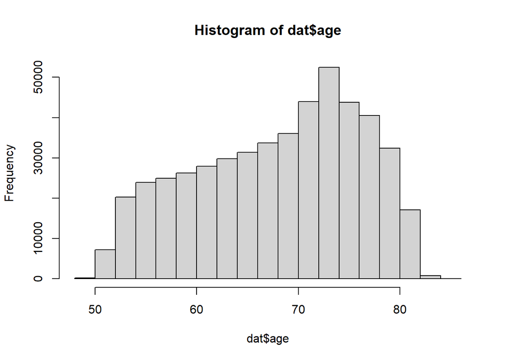

```r
hist(dat$age)
```

```r
table(dat$sex) / nrow(dat)
```

```
##
##         0         1
## 0.5448383 0.4551617
```

How many individuals tested:

```r
table(dat$tested)
```

```
##
##      0      1
## 486488   5904
```

## Illustration of collider bias

Age, sex and BMI all strongly influence the likelihood of being tested:

```r
summary(glm(tested ~ age + sex + bmi, data=dat, family="binomial"))
```

```
##
## Call:
## glm(formula = tested ~ age + sex + bmi, family = "binomial",
##     data = dat)
##
## Deviance Residuals:
##     Min       1Q   Median       3Q      Max
## -0.3405  -0.1628  -0.1527  -0.1434   3.1402
##
## Coefficients:
##              Estimate Std. Error z value Pr(>|z|)
## (Intercept) -5.922371   0.132640 -44.650  < 2e-16 ***
## age          0.006487   0.001634   3.969 7.22e-05 ***
## sex          0.103816   0.026224   3.959 7.53e-05 ***
## bmi          0.036462   0.002500  14.585  < 2e-16 ***
## ---
## Signif. codes:  0 '***' 0.001 '**' 0.01 '*' 0.05 '.' 0.1 ' ' 1
##
## (Dispersion parameter for binomial family taken to be 1)
##
##     Null deviance: 63971  on 492391  degrees of freedom
## Residual deviance: 63730  on 492388  degrees of freedom
## AIC: 63738
##
## Number of Fisher Scoring iterations: 7
```

Hence we would expect the relationships between these variables to be skewed within the tested sample. For example, this is the relationship between age and sex in the total sample

```r
mod1 <- summary(lm(age ~ sex, dat))
coefficients(mod1) %>% kable
```

|  | Estimate | Std. Error | t value | Pr(>\|t\|) |
| --- | --- | --- | --- | --- |
| (Intercept) | 68.2695118 | 0.0156525 | 4361.57945 | 0 |
| sex | 0.3703387 | 0.0232006 | 15.96243 | 0 |

And here it is amongst only those tested:

```r
mod2 <- summary(lm(age ~ sex, dat, subset=dat$tested==1))
coefficients(mod2) %>% kable
```

|  | Estimate | Std. Error | t value | Pr(>\|t\|) |
| --- | --- | --- | --- | --- |
| (Intercept) | 67.67524 | 0.1589147 | 425.85894 | 0 |
| sex | 2.54350 | 0.2278876 | 11.16121 | 0 |

Note that the association is around **7 times larger** in the tested subset.

```r
mod3 <- summary(lm(bmi ~ sex, dat))
coefficients(mod3) %>% kable
```

|  | Estimate | Std. Error | t value | Pr(>\|t\|) |
| --- | --- | --- | --- | --- |
| (Intercept) | 27.0942063 | 0.0092111 | 2941.48475 | 0 |
| sex | 0.7419068 | 0.0136530 | 54.34035 | 0 |

and here in the subsample:

```r
mod4 <- summary(lm(bmi ~ sex, dat, subset=dat$tested==1))
coefficients(mod4) %>% kable
```

|  | Estimate | Std. Error | t value | Pr(>\|t\|) |
| --- | --- | --- | --- | --- |
| (Intercept) | 28.1546983 | 0.0963758 | 292.134651 | 0.0000000 |
| sex | 0.4174368 | 0.1382052 | 3.020413 | 0.0025351 |

where the association almost halves.

## Inverse probability weights

If the tested individuals are a subset of the entire sample, then it is possible to generate probabilities for individuals being included in the tested subsample based on the colliding variables. The inverse of these probabilities can be used to weight the association estimate towards being representative of the overall sample.

First find which variables associate with being tested. Begin with marginal effects

```r
mod5 <- glm(tested ~ age + sex + bmi, data=dat, family="binomial")
prs1 <- fitted.values(mod5)
coefficients(summary(mod5)) %>% kable
```

|  | Estimate | Std. Error | z value | Pr(>\|z\|) |
| --- | --- | --- | --- | --- |
| (Intercept) | -5.9223706 | 0.1326401 | -44.649915 | 0.00e+00 |
| age | 0.0064868 | 0.0016344 | 3.968823 | 7.22e-05 |
| sex | 0.1038164 | 0.0262241 | 3.958822 | 7.53e-05 |
| bmi | 0.0364623 | 0.0025000 | 14.585195 | 0.00e+00 |

It’s important to also test for interactions between variables (Groenwold, Palmer, and Tilling 2020).

```r
mod6 <- glm(tested ~ bmi + age + sex + bmi * age + bmi * sex + age * sex + age * bmi * sex, data=dat, family="binomial")
coefficients(summary(mod6)) %>% kable
```

|  | Estimate | Std. Error | z value | Pr(>\|z\|) |
| --- | --- | --- | --- | --- |
| (Intercept) | -2.4386662 | 0.7600262 | -3.208661 | 0.0013335 |
| bmi | -0.0469310 | 0.0267885 | -1.751907 | 0.0797899 |
| age | -0.0452259 | 0.0112794 | -4.009590 | 0.0000608 |
| sex | -3.9881129 | 1.3111898 | -3.041598 | 0.0023533 |
| bmi:age | 0.0012435 | 0.0003960 | 3.140162 | 0.0016885 |
| bmi:sex | 0.0604504 | 0.0458599 | 1.318153 | 0.1874523 |
| age:sex | 0.0598076 | 0.0189730 | 3.152243 | 0.0016202 |
| bmi:age:sex | -0.0008918 | 0.0006627 | -1.345629 | 0.1784222 |

Curiously the marginal BMI effect appears to be captured by interaction terms only. Centering the marginal variables may be more appropriate when estimating interactions.

```r
dat$bmixage <- scale(dat$bmi) * scale(dat$age)
dat$bmixsex <- scale(dat$bmi) * scale(dat$sex)
dat$agexsex <- scale(dat$age) * scale(dat$sex)
dat$agexsexxbmi <- scale(dat$age) * scale(dat$sex) * scale(dat$bmi)
mod7 <- glm(tested ~ bmi + age + sex + bmixage + bmixsex + agexsex + agexsexxbmi, data=dat, family="binomial")
coefficients(summary(mod7)) %>% kable
```

|  | Estimate | Std. Error | z value | Pr(>\|z\|) |
| --- | --- | --- | --- | --- |
| (Intercept) | -5.8669485 | 0.1324589 | -44.2926117 | 0.0000000 |
| bmi | 0.0379081 | 0.0025664 | 14.7706579 | 0.0000000 |
| age | 0.0049735 | 0.0016671 | 2.9832590 | 0.0028520 |
| sex | 0.0890447 | 0.0271695 | 3.2773819 | 0.0010477 |
| bmixage | 0.0325030 | 0.0125774 | 2.5842439 | 0.0097593 |
| bmixsex | -0.0013862 | 0.0124699 | -0.1111627 | 0.9114873 |
| agexsex | 0.1427313 | 0.0134988 | 10.5736388 | 0.0000000 |
| agexsexxbmi | -0.0172329 | 0.0128066 | -1.3456290 | 0.1784222 |

Here the marginal effects are all retained.

We can generate the probabilities of each individual being tested based on these variables using:

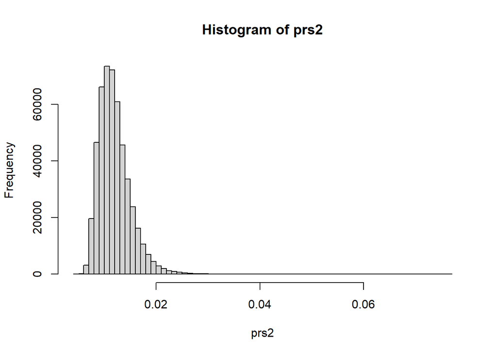

```r
prs2 <- fitted.values(mod7)
hist(prs2, breaks=100)
```

It is also important to consider non-linearities in the relationship between testing and age and BMI, which are continuous. There appears to be a quadratic relationship between age and testing and a cubic relationship between BMI and testing.

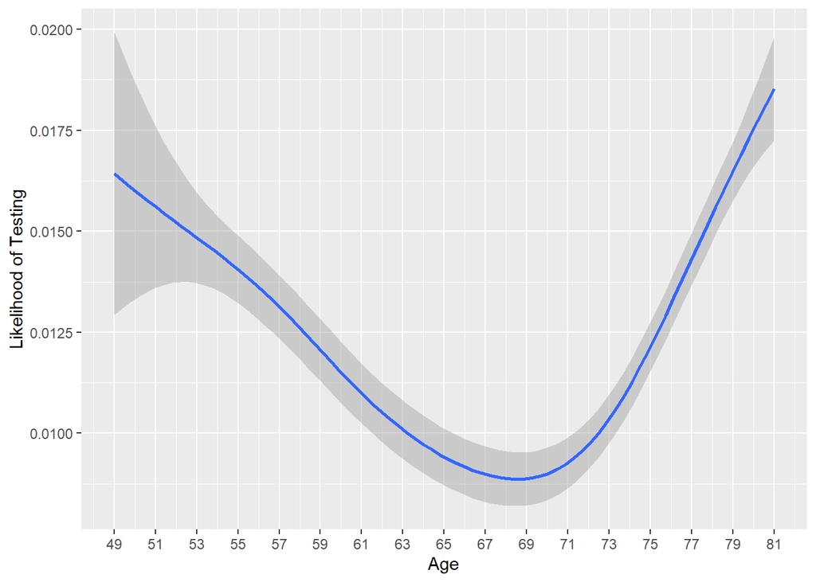

```r
# Age plot
ggplot(dat[dat$age<82,],aes(x=age, y=tested)) +
  geom_smooth(method="gam",formula=y~s(x)) +
  xlab("Age") + ylab("Likelihood of Testing") +
  scale_x_continuous(breaks=seq(min(dat$age),82,by=2))
```

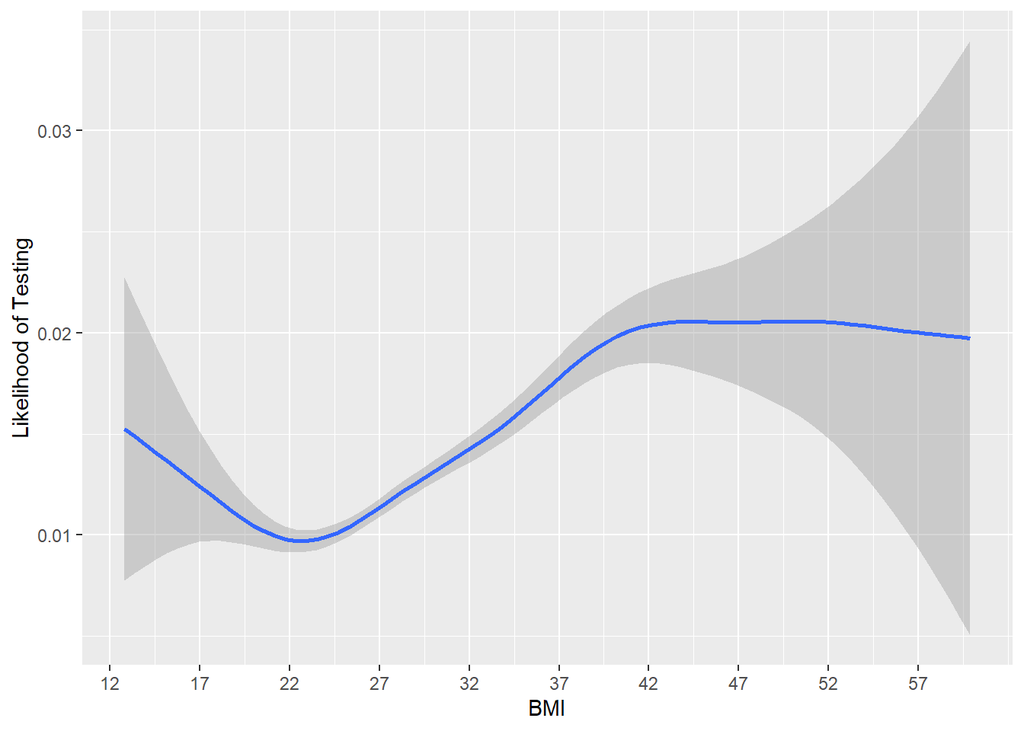

```r
# BMI plot
ggplot(dat[dat$bmi<60,],aes(x=bmi, y=tested)) +
   geom_smooth(method="gam",formula=y~s(x)) +
  xlab("BMI") + ylab("Likelihood of Testing") +
  scale_x_continuous(breaks=seq(12,60,by=5))
```

```r
mod8 <- glm(tested ~ sex + poly(age, 2) + poly(bmi, 3) + bmixage + bmixsex + agexsex + agexsexxbmi, data=dat, family="binomial")
summary(mod8)
```

```
##
## Call:
## glm(formula = tested ~ sex + poly(age, 2) + poly(bmi, 3) + bmixage +
##     bmixsex + agexsex + agexsexxbmi, family = "binomial", data = dat)
##
## Deviance Residuals:
##     Min       1Q   Median       3Q      Max
## -0.3560  -0.1657  -0.1467  -0.1340   3.1318
##
## Coefficients:
##                 Estimate Std. Error  z value Pr(>|z|)
## (Intercept)    -4.505016   0.018849 -239.006  < 2e-16 ***
## sex             0.090564   0.027568    3.285  0.00102 **
## poly(age, 2)1  27.063717   8.678689    3.118  0.00182 **
## poly(age, 2)2 140.043970   8.604877   16.275  < 2e-16 ***
## poly(bmi, 3)1 125.971024   8.872164   14.198  < 2e-16 ***
## poly(bmi, 3)2  14.102663   8.422602    1.674  0.09406 .
## poly(bmi, 3)3 -28.860842   9.025124   -3.198  0.00138 **
## bmixage         0.019016   0.011397    1.669  0.09521 .
## bmixsex        -0.002089   0.012433   -0.168  0.86659
## agexsex         0.115827   0.012389    9.349  < 2e-16 ***
## agexsexxbmi    -0.011824   0.011538   -1.025  0.30547
## ---
## Signif. codes:  0 '***' 0.001 '**' 0.01 '*' 0.05 '.' 0.1 ' ' 1
##
## (Dispersion parameter for binomial family taken to be 1)
##
##     Null deviance: 63971  on 492391  degrees of freedom
## Residual deviance: 63342  on 492381  degrees of freedom
## AIC: 63364
##
## Number of Fisher Scoring iterations: 7
```

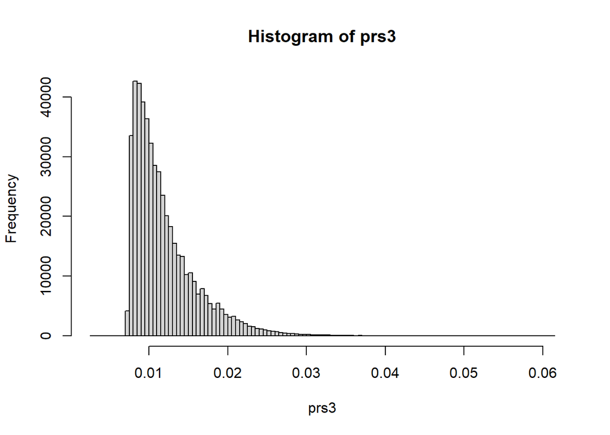

```r
prs3 <- fitted.values(mod8)
hist(prs3, breaks=100)
```

The probabilities are largely clustered close to zero, so when using the inverse of these probabilities for weights there can be potential instability that comes from dividing by small numbers. Stabilising the weight, by multiplying by the probability of being tested, can avoid this issue (Sayon-Orea et al. 2020).

```r
p <- mean(as.numeric(dat$tested))
ipw1 <- ifelse(dat$tested==1, p/prs1, (1-p)/prs1)
ipw2 <- ifelse(dat$tested==1, p/prs2, (1-p)/prs2)
ipw3 <- ifelse(dat$tested==1, p/prs3, (1-p)/prs3)
```

# Comparison of full sample, unweighted and weighted estimates

## Age and sex association

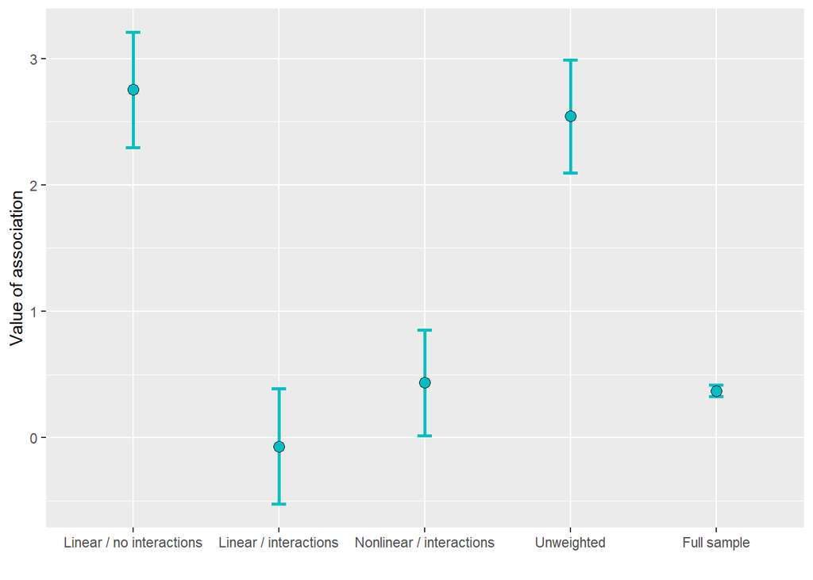

```r
ggplot() + geom_errorbar(data=out[out$assoc=="as",], mapping=aes(x=as.factor(model), ymin=beta-1.96*se,    ymax=beta+1.96*se), width=0.1, size=1, color="#00BFC4") +
geom_point(data=out[out$assoc=="as",], mapping=aes(x=as.factor(model), y=beta), size=3, shape=21, fill="#00BFC4") + scale_x_discrete(labels=c("Linear / no interactions", "Linear / interactions",  "Nonlinear / interactions", "Unweighted", "Full sample")) + xlab("") + ylab("Value of association")
```

## BMI and sex association

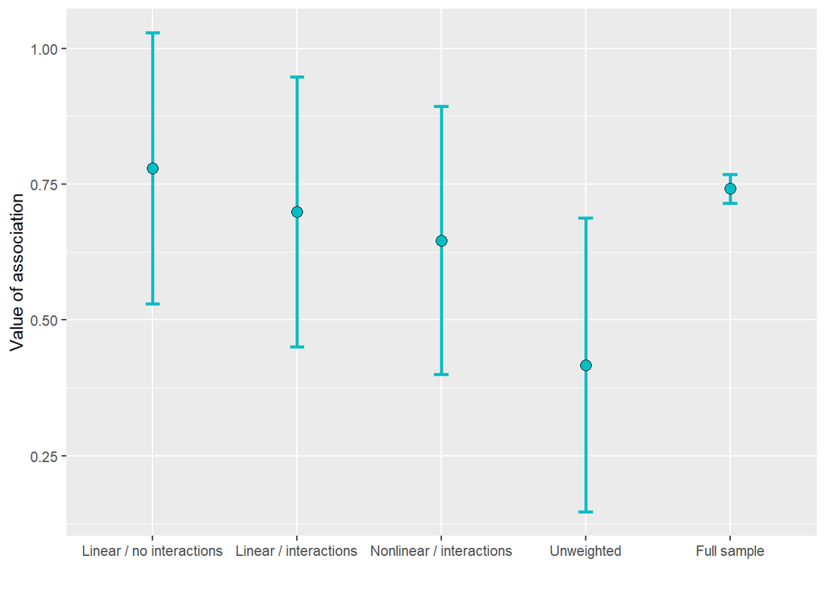

```r
ggplot() + geom_errorbar(data=out[out$assoc=="bs",], mapping=aes(x=as.factor(model), ymin=beta-1.96*se,    ymax=beta+1.96*se), width=0.1, size=1, color="#00BFC4") +
geom_point(data=out[out$assoc=="bs",], mapping=aes(x=as.factor(model), y=beta), size=3, shape=21, fill="#00BFC4") + scale_x_discrete(labels=c("Linear / no interactions", "Linear / interactions",  "Nonlinear / interactions", "Unweighted", "Full sample")) + xlab("") + ylab("Value of association")
```

## BMI and age association

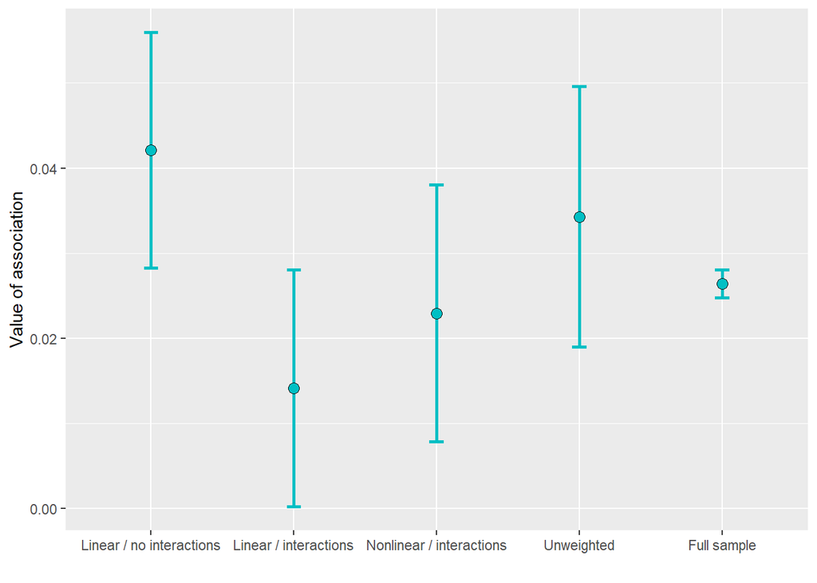

```r
ggplot() + geom_errorbar(data=out[out$assoc=="ab",], mapping=aes(x=as.factor(model), ymin=beta-1.96*se,    ymax=beta+1.96*se), width=0.1, size=1, color="#00BFC4") +
geom_point(data=out[out$assoc=="ab",], mapping=aes(x=as.factor(model), y=beta), size=3, shape=21, fill="#00BFC4") + scale_x_discrete(labels=c("Linear / no interactions", "Linear / interactions",  "Nonlinear / interactions", "Unweighted", "Full sample")) + xlab("") + ylab("Value of association")
```

# Sensitivity analyses

We now present two sensitivity analyses which can be used when direct estimation of the probability weights is limited or not possible. Zhao et al (2019) is most appropriately used when probability weights can be estimated but are likely to be misspecified (e.g. missing an important predictor). Tudball et al (2020) is most appropriately used when weights cannot be estimated but there is external information on the target population (e.g. survey response rate, population means).

We will attempt to estimate average BMI in the full UK Biobank population using data on the tested sub-sample. The tested sub-sample’s average BMI is around 1 unit higher than the full sample.

```r
dattest <- dat[dat$tested==1,]

rbind(
  tibble(
    sample="full sample",
    mean=round(mean(dat$bmi),2),
    ci_lower=round(mean(dat$bmi) - 1.96*sqrt(var(dat$bmi)/nrow(dat)),2),
    ci_upper=round(mean(dat$bmi) + 1.96*sqrt(var(dat$bmi)/nrow(dat)
    ),2)
  ),
  tibble(
    sample="sub-sample",
    mean=round(mean(dattest$bmi),2),
    ci_lower=round(mean(dattest$bmi) - 1.96*sqrt(var(dattest$bmi)/nrow(dattest)),2),
    ci_upper=round(mean(dattest$bmi) + 1.96*sqrt(var(dattest$bmi)/nrow(dattest)),2)
  )
) %>% kable
```

| sample | mean | ci_lower | ci_upper |
| --- | --- | --- | --- |
| full sample | 27.43 | 27.42 | 27.45 |
| sub-sample | 28.36 | 28.22 | 28.49 |

## Zhao, Small, and Bhattacharya (2019)

Suppose we only measure BMI in the tested sub-sample and not the full UK Biobank sample. Our probability weights are likely to be misspecified if we estimate them using only age and sex as covariates. The sensitivity parameter in Zhao, Small, and Bhattacharya (2019) is the largest amount that the estimated weights differ from the true weights on the odds ratio scale. Given this parameter, this method provides an interval of possible values for means and average treatment effects.

```r
prs_mis <- as.vector(fitted.values(glm(tested ~ sex + age + age*sex, data=dat, family="binomial")))
prs_or <- (prs2/(1-prs2))/(prs_mis/(1-prs_mis))
Gamma <- max(1/min(prs_or),max(prs_or))
print(paste("True sensitivity parameter: ",round(Gamma,2),sep=""))
```

```
## [1] "True sensitivity parameter: 5.43"
```

```r
sens1 <- bootsens::extrema.md(A=dat$tested, Y=dat$bmi, X <- as.matrix(dat[,!(names(dat) %in% c("tested"))]), gamma=log(Gamma), estimand="all")

sens1_ci <- bootsens::bootsens.md(A=dat$tested, Y=dat$bmi, X <- as.matrix(dat[,!(names(dat) %in% c("tested"))]), gamma=log(Gamma), estimand="all", parallel=F, B=500)

out1 <- list(beta_min=sens1[1], beta_max=sens1[2], beta_lower=sens1_ci[1], beta_upper=sens1_ci[2])

tibble(
    method="Zhao et al (2019)",
    lower_ci=round(out1$beta_lower,2),
    lower_bound=round(out1$beta_min,2),
    upper_bound=round(out1$beta_max,2),
    upper_ci=round(out1$beta_upper,2)
) %>% kable
```

| method | lower_ci | lower_bound | upper_bound | upper_ci |
| --- | --- | --- | --- | --- |
| Zhao et al (2019) | 22.13 | 22.25 | 34.84 | 34.99 |

The resulting bounds, while quite wide, contain average BMI in the full UK Biobank population. One reason these bounds are so wide is because this method is non-parametric, that is, it does not restrict the way in the true weights may differ from the estimated weights. The trade-off is between precision (i.e. a tight bound) and accuracy (i.e. a bound that contains average BMI in the full UK Biobank population).

## Tudball et al. (2020)

Suppose we only observe the tested sub-sample. Estimating probability weights is no longer possible since we do not observe anyone who has not been tested. The two sensitivity parameters in Tudball et al. (2020) are the smallest and largest probabilities of being tested (e.g. 1% and 90%). We then select a model for the probability weights as before and this method places bounds on the possible values of average BMI in the full UK Biobank population.

A non-parametric version of this method also exists but here we present the parametric version using a logistic model for the weights. As discussed above, the parametric version results in tighter bounds but carries the risk of misspecification of the weights.

We first define the numerator and denominator of estimator. Since this is a mean, the numerator is the BMI variable and the denominator is a vector of ones. We also format the variables we wish to use in our probability weights. We select age, sex, BMI and their interactions.

```r
fT <- dattest$bmi
gT <- rep(1,NROW(dattest))

D <- as.data.frame(dattest[,c('age','sex','bmi')])
D$agexsex <- D$age*D$sex
D$agexbmi <- D$age*D$bmi
D$sexxbmi <- D$sex*D$bmi
D$agexsexxbmi <- D$age*D$sex*D$bmi
```

We then define our lower bound (a) and upper bound (b) for the probability of being tested. For illustration, we use the true values estimated from the linear model with interactions.

```r
a <- min(prs2)
b <- max(prs2)
```

We also select our constraints and other options for the solver.

```r
mycons <- list(
  list('resp', mean(dat$tested)),
  list('covmean', D$sex, mean(dat$sex))
)

nlopts <- list("xtol_rel"=1e-8, "ftol_rel"=1e-10, "maxeval"=-1)
opts <- list("alpha2"=0.025, "grid_bound"=4, "grid_fine"=8, "tol"=1e-4, "maxeval"=3e2, "newton_step"=0.1)
```

We are now ready to generate our bounds for average BMI.

```r
sens2 <- find_bound(a,b,fT,gT,D,constraints=mycons,opts,nlopts)
```

```
## [1] "Finding the nearest valid parameters from 256 starting values..."
## [1] "Found 26 valid starting parameter(s). Finding bounds..."
```

```r
sens2_upper <- sens2$beta_max + qnorm(0.9875)*sens2$se_max
sens2_lower <- sens2$beta_min - qnorm(0.9875)*sens2$se_min

out2 <- list(beta_min=sens2$beta_min, beta_max=sens2$beta_max, beta_lower=sens2_lower, beta_upper=sens2_upper)

tibble(
  method="Tudball et al (2020)",
  lower_ci=round(out2$beta_lower,2),
  lower_bound=round(out2$beta_min,2),
  upper_bound=round(out2$beta_max,2),
  upper_ci=round(out2$beta_upper,2)
  ) %>% kable
```

| method | lower_ci | lower_bound | upper_bound | upper_ci |
| --- | --- | --- | --- | --- |
| Tudball et al (2020) | 26.83 | 26.97 | 29.21 | 29.4 |

As we can see, this method produces an informative bound for average BMI in the full sample.

# References

Griffith, Gareth, Tim T Morris, Matt Tudball, Annie Herbert, Giulia Mancano, Lindsey Pike, Gemma C Sharp, et al. 2020. “Collider bias undermines our understanding of COVID-19 disease risk and severity.” *medRxiv*. https://doi.org/10.1101/2020.05.04.20090506.

Groenwold, Rolf H H, Tom M Palmer, and Kate Tilling. 2020. “To adjust or not to adjust ? What to do when a ‘confounder’ is only measured after exposure.” https://osf.io/sj7ch/.

Sayon-Orea, Carmen, Conchi Moreno-Iribas, Josu Delfrade, Manuela Sanchez-Echenique, Pilar Amiano, Eva Ardanaz, Javier Gorricho, Garbiñe Basterra, Marian Nuin, and Marcela Guevara. 2020. “Inverse-probability weighting and multiple imputation for evaluating selection bias in the estimation of childhood obesity prevalence using data from electronic health records.” *BMC Medical Informatics and Decision Making* 20 (1): 9. https://doi.org/10.1186/s12911-020-1020-8.

Tudball, Matthew J, Qingyuan Zhao, Rachael A Hughes, Kate Tilling, and Jack Bowden. 2020. “An interval estimation approach to sample selection bias.” https://arxiv.org/abs/1906.10159.

Zhao, Qingyuan, Dylan S Small, and Bhaswar B Bhattacharya. 2019. “Sensitivity analysis for inverse probability weighting estimators via the percentile bootstrap.” https://arxiv.org/abs/1711.11286.